# 0928_homework

홍영화

2018년 9월 28일

## 도서관의 공간 변화

### 도서관은 교육시설이 아닌 여가시설로 탈바꿈하고 있다. 이제 더이상 딱딱하고 조용한 공간이 아닌, 지역 일자리 센터와 카페, 복합문화적 시설, 여가 시설로 탈바꿈되고 있다.

### 그렇다면 경제적 여유가 늘어나거나, 1인 가구가 늘어나면 도서관 이용자 수가 늘어날까? 혹은 실업자 수가 늘어나거나 소비자 물가지수가 줄어들면 도서관 이용자 수가 늘어날까?

### 공공도서관 이용자 수 데이터와 각종 경제지표, 사회지표를 연관지어보고자 한다.

- 데이터를 선택한 이유
- 주전공에 연관된 주제를 정하고 싶었다.
- 도서관이 지역 일자리 센터, 여가시설의 역할을 정말 수행할 수 있는가에 대한 답을 원한다.
- 적절한 상관관계를 추출해냄으로써 도서관의 공간 변화는 긍정적인 변화임을 주장하고자 한다.

| 2017 | 도서관 방문자수 | 자료실 이용자수 | 연간 대출 책수 |
| --- | --- | --- | --- |
| 시,도도서관 | 40,635,677 | 33,044,867 | 15,037,940 |
| 교육청도서관 | 23,402,253 | 15,306,638 | 7,524,764 |
| 시립도서관 | 210,636 | 202,860 | 99,341 |
| 합계 | 64,248,566 | 48,554,365 | 22,662,045 |

[데이터링크](http://data.seoul.go.kr/dataList/datasetView.do?serviceKind=2&infId=10651&stcSrl=10651&srvType=S)

### 별마당 도서관

#### 2800㎡ 넓은 공간에 사방에는 5만여 권의 책을 품은 13m 높이의 대형 서가를 가진 도서관으로, 코엑스몰과 경계선을 갖지 않는다. 쇼핑몰과 도서관이 이어져 있어 딱딱한 도서관의 공간을 탈피했다.

[figure not shown]

별마당 도서관

### 다케오 도서관

#### 연간 이용자가 1만명에 그쳤던 도서관이 재개관함으로써 100만명을 불러오는 지역 명소가 되었다. 도서관 내에 커피점이 있고, 서점도 있어 기존의 도서관 개념을 벗어났다.

[figure not shown]

다케오 도서관

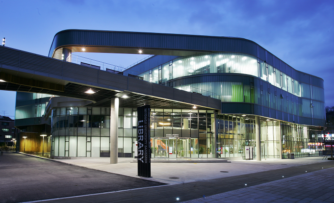

명지대 도서관